# Graphical Comparison

He Jinlin & Wang Yuan

January 26, 2017

## Data Used

*Sample A:* All entries with unlimited play time  
*Sample B:* Entries with one additional variable that involves music (a subset of *Sample A*)  
*Sample C:* Entries identified by the same group ID (a subset of *Sample A*)

- Response Variables
  - TimeUsed
  - NumErrors
- Factors of Interest
  - NumShapes
  - TimerDisplay
  - MatchingScheme

### Cleaning the data

1. Loading dataset from the website:

```r
#install.packages("data.table")
#library(data.table)
shape <- read.csv("~/Desktop/MAP/Original.csv", stringsAsFactors = F)
#shape <- fread("http://kuiper.pearsoncmg.com/shapesplosion/webreporter.php?game=PerfectionFlash&groupID=&winlose=both&random=false&rows=&type=csv", stringsAsFactors = F)
```

2. Using data with unlimited playtime yet playtime > 0:

```r
shape_untime = shape[shape$requestedTime==0,]
shape_untimed = shape_untime[shape_untime$timeUsed!=0,]
```

```r
shape_untimed_sec <-mutate(shape_untimed, TimeUsedSec = shape_untimed$timeUsed/1000)
```

4. Converting the categorical variables such as numShapes in numerical forms into factors

```r
shape_untimed_sec$numShapes = as.factor(shape_untimed_sec$numShapes)
shape_untimed_sec$timerDisplay = as.factor(shape_untimed_sec$timerDisplay)
shape_untimed_sec$matchingScheme = as.factor(shape_untimed_sec$matchingScheme)
```

5. Sample B was extracted from Sample A by identiying entries with any of the following ‘v1lable’ names :  
   “Music” “music” “song” “Song” “MUSICON MUSIC”

```r
music_untimed <- shape_untimed_sec[tolower(strtrim(shape_untimed_sec$v1label,2))=="mu" |                              tolower(strtrim(shape_untimed_sec$v1label,2))=="so",]
```

## Approach 1: Same Plots With Different Sample Size (*Sample A* and *Sample B*)

### ‘TimeUsed’ as Response Variable

```r
shape_untimed_truncate = shape_untimed_sec[shape_untimed_sec$TimeUsedSec<=1000,]
```

Then y-axis (TimeUsed) is logged

### 1. Log(Timeused) ~ numShapes, colored by TimerDisplay

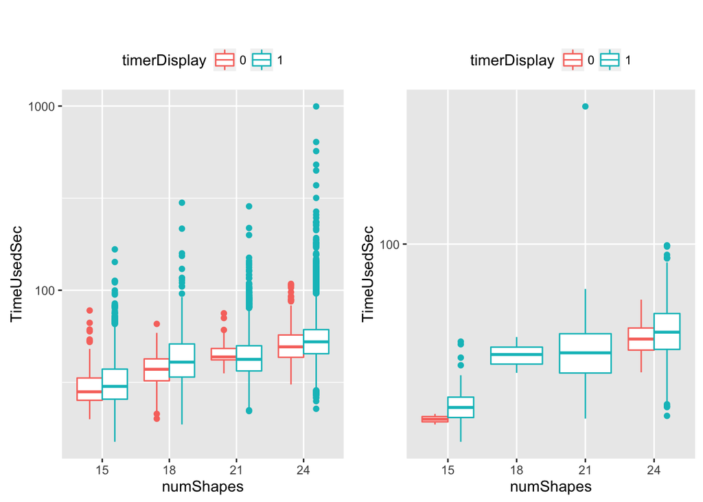

### 2: Log(Timeused) ~ numShapes, colored by MatchingScheme

**Note: We are still working on the code to nicely juxatpose two graphs together without squeeshing either. Here the purple plots on the left corresponds to ‘shape’.**

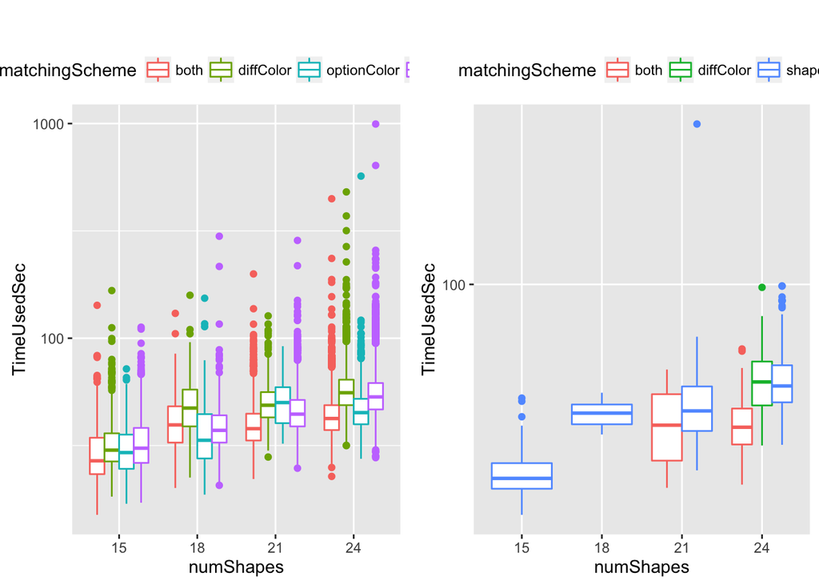

### 3 Log(timeused) ~ matching scheme, colored by Timer

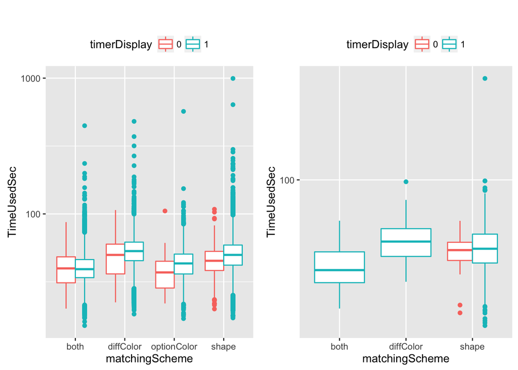

### 4 Log(timeused) ~ matching scheme, colored by numShapes

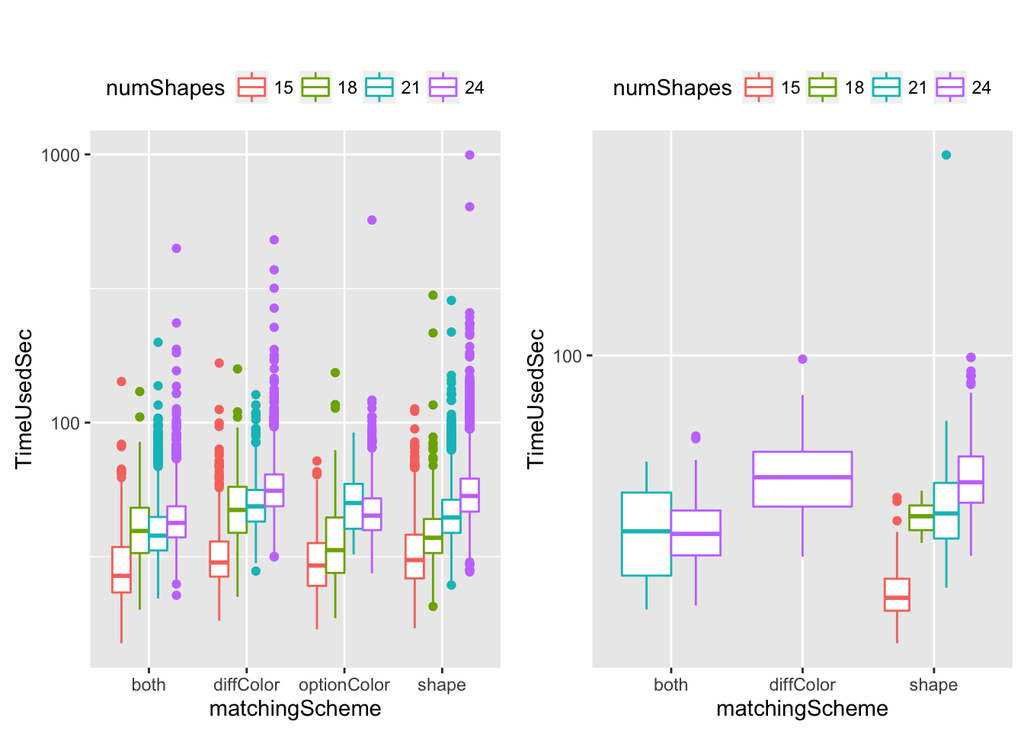

### 5 Log(timeused) ~ timerDisplay, colored by matchingScheme

**Note: still working on the code to nicely juxatpose two graphs together without squeeshing either. Here the purple plots on the left is ‘shape’.**

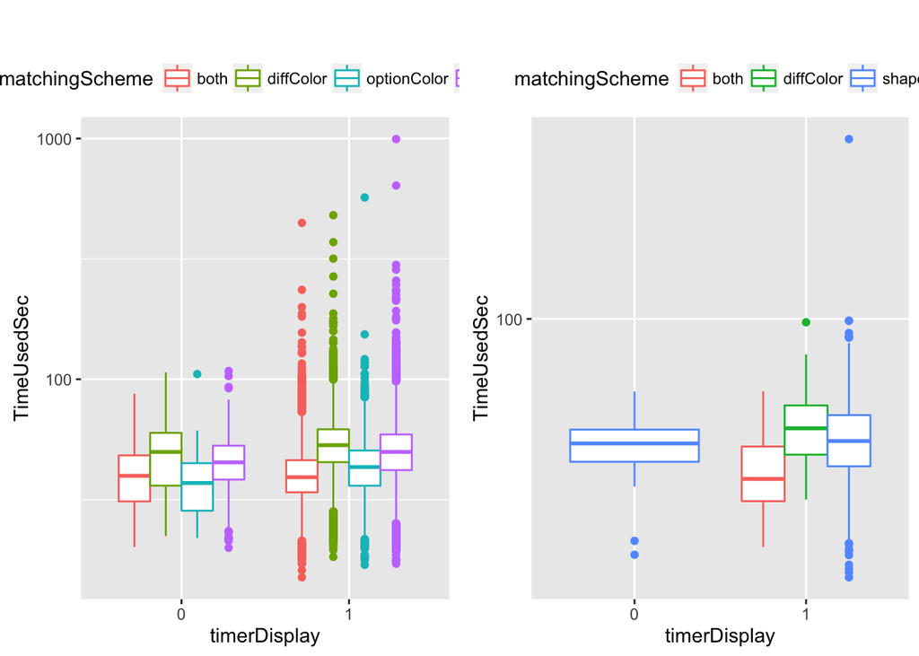

### 6 Log(timeused) ~ timerDisplay, colored by numShapes

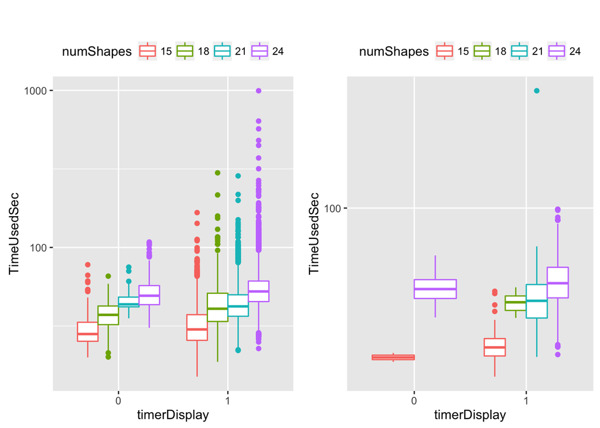

### 7 Log(timeused) ~ numShapes, colored by matchingScheme, facet by timerDisplay

**Note: This is a three-way plots. It gives more comprehensive information all at once, but we find it difficult to provide readers with a focused sets of information.** **We are still working on the code to nicely juxatpose two graphs together without squeeshing either. Here the purple plots on the left is ‘shape’.**

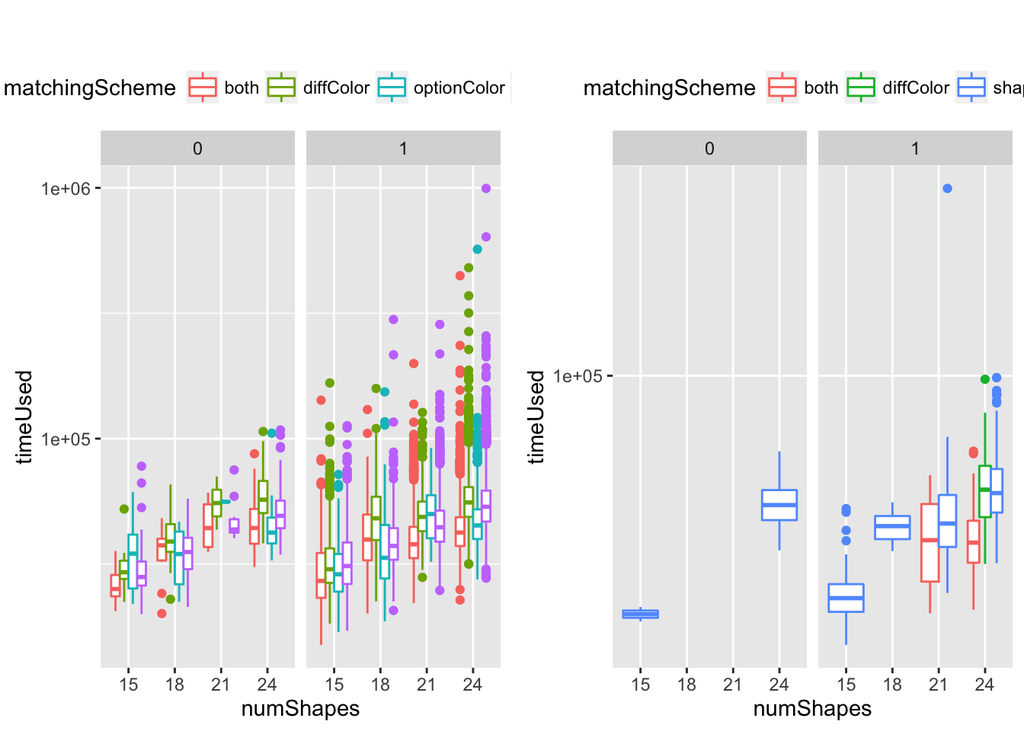

## Approach 2: Plots of Same Dataset With Different Number of Variables

### NumError as Response Variable

**Filter data by groupID (top 5 most used group IDs)**

```r
#groupID_count <- count_(shape,"groupID")
shape_HotchkissStudent16 <- shape_untimed[shape_untimed$groupID=="HotchkissStudent16",]
shape_6002T6 <- shape_untimed[shape_untimed$groupID=="6002T6",]
shape_6002T2 <- shape_untimed[shape_untimed$groupID=="6002T2",]
shape_6002T3 <- shape_untimed[shape_untimed$groupID=="6002T3",]
shape_6002T4 <- shape_untimed[shape_untimed$groupID=="6002T4",]
```

### 8.Effects of looking at one additional fixed variable (‘TimerDisplay’)

### *Sample A*

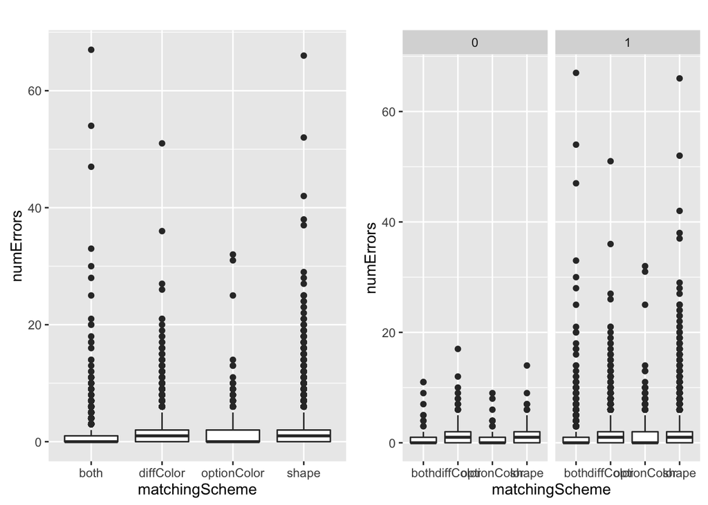

### 9. *Sample C*

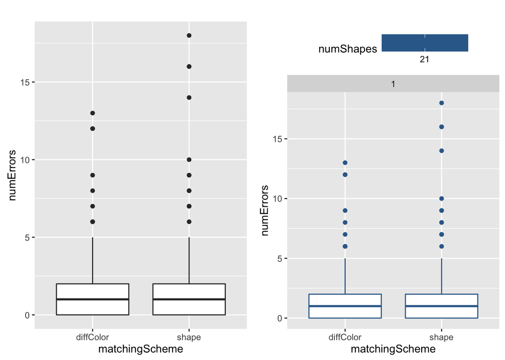

Though ‘colored by’ here does not add any new information, but we still decide to include the third variable ‘numShapes’ because it still tells us that the all entries in this group used 21 shapes.

### 10. Effects of looking at two additional fixed variable (TimerDisplay, NumShapes)

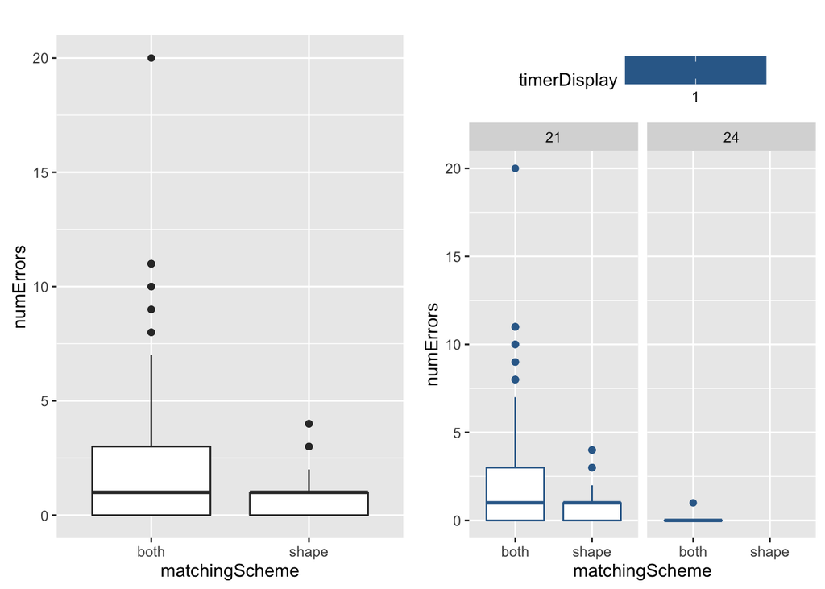

### 11.

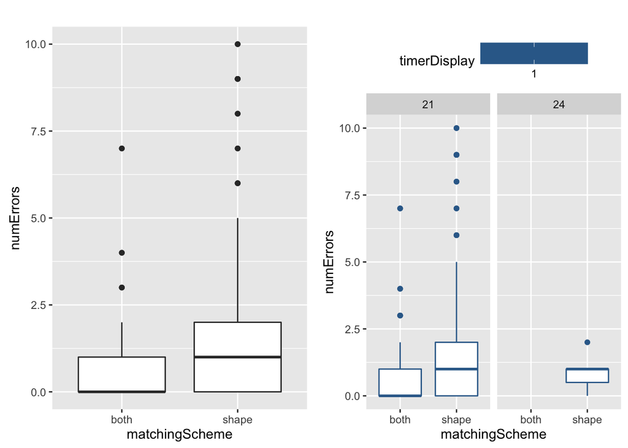

### 12.

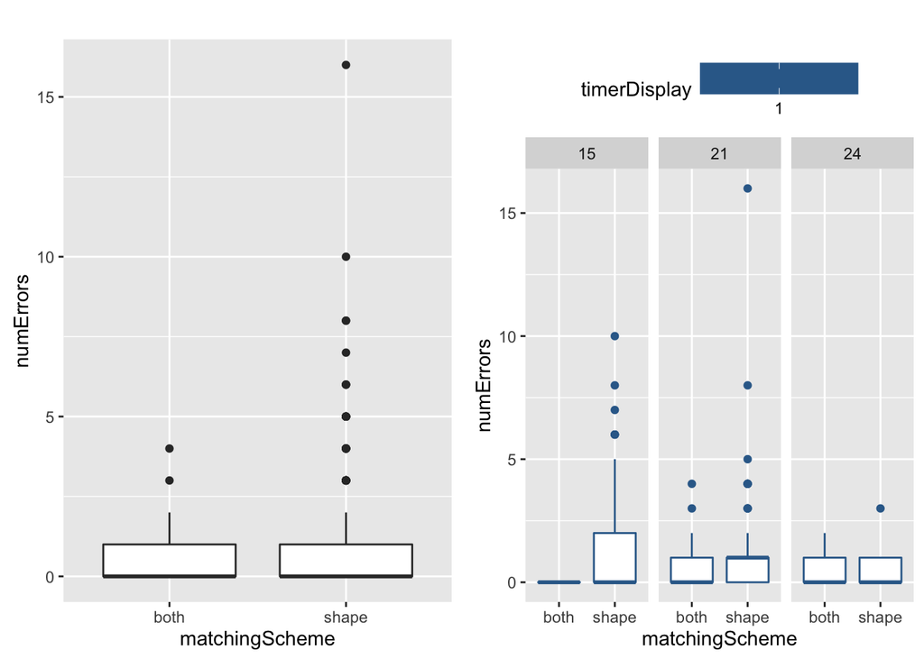

### 13.

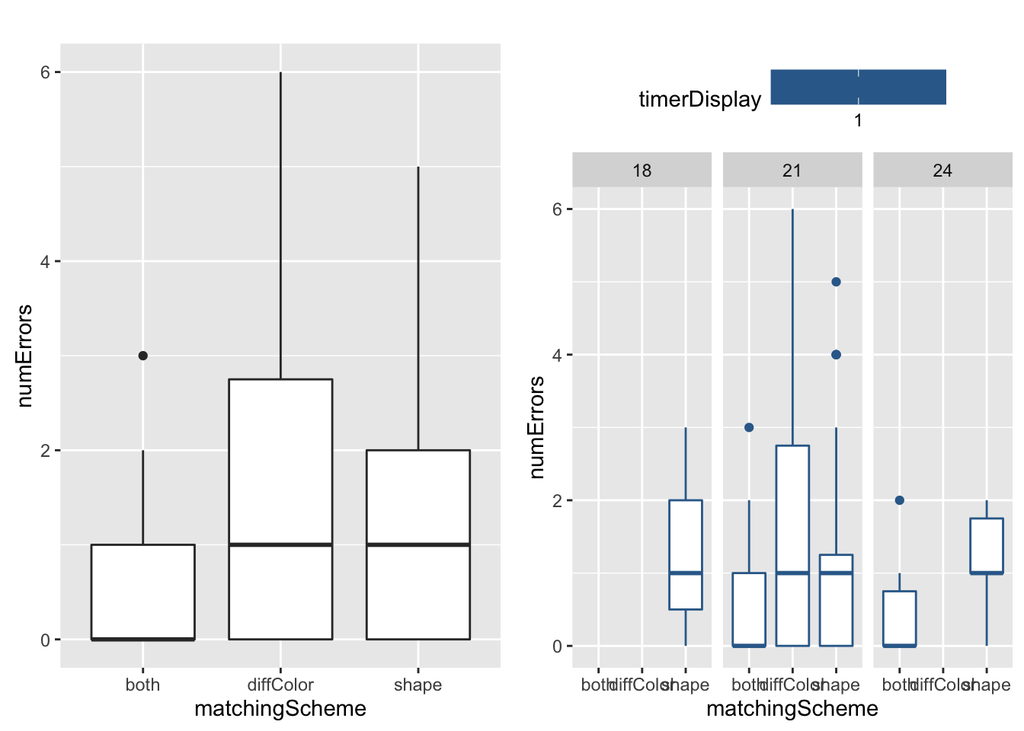